# Auditory Distance Perception Study Power Analysis

Lucas Gonzalez - Damian Payo - Manuel Eguia

21/7/2023

## Abstract

The analysis of results obtained from PAD experiment in June and July 2023 in room 27 of the National University of Quilmes is presented.

Two experiments were carried out. In experiment 1(a), 23 subjects participated (16 males, 6 females, and 1 non-binary) with ages ranging from 19 to 60 years (mean = 29, standard deviation = 9.69).

Experiment 1(b), involved 22 subjects (14 males, and 8 females) aged 19 to 63 years (mean = 34.36, standard deviation = 12.45).

## Data Loading

The data for experiment 1(a) are in the **Data_1k** folder. There are 69 .csv files corresponding to each condition/block for each subject.  
- “nsub” is the ID given to the subject  
- “distancia” corresponds to the actual distance of the sound stimulus. It can contain 12 values.  
- “respuesta” is the subject’s response to the stimulus  
- “bloque” is not the actual data of the block order. It will be corrected later.

## Logarithmic and labeled values

We apply logarithms to the response and distance observations in order to make linear regressions between the variables and obtain a slope indicating distance compression

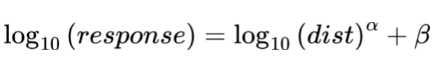

## Outlier Detection and Removal by Response

We applied the *Minimum Covariance Determinant* criteria to detect multivariate outliers.

We eliminated 938 observations from the total of 4968 with this method.

## Linear Regressions

We performed a linear regression for each condition per subject. We generate a new tibble containing a slope value for each condition per subject (nsub).

If slope is 1, it means that the compression ratio is 1 to 1, it means that there is no compression. If it is higher than 1, it means that there is expansion. If it is less than 1, it means that there is distance compression.

In addition, all the residuals (distance to linear regression) are put together in a vector (sresids). Finally, a variable is added with the order of the blocks by appearance during the experiment (order).

## Subject dismissal

Before the evaluation, subjects were asked to complete a form with demographic information. Subject number 3 expressed hearing impairment in one ear, so we decided to exclude his data from the analysis.

### Observation of normality in residuals

We plotted a histogram and qqplot with the residuals of the linear regression performed for each subject.

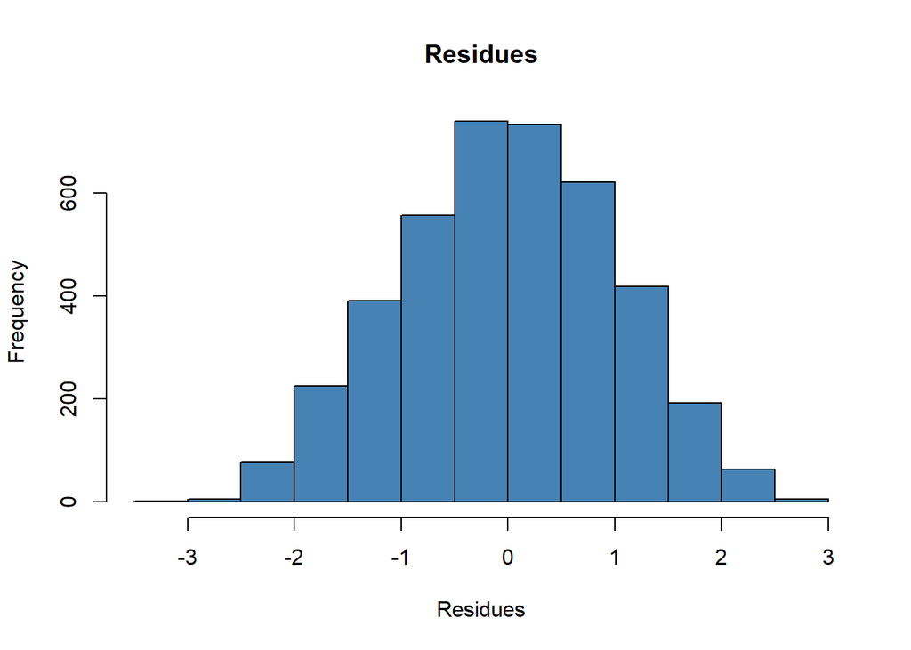

```r
# Histogram & QQ Plot
hist(sresids, col='steelblue', main='Residues',xlab="Residues")
```

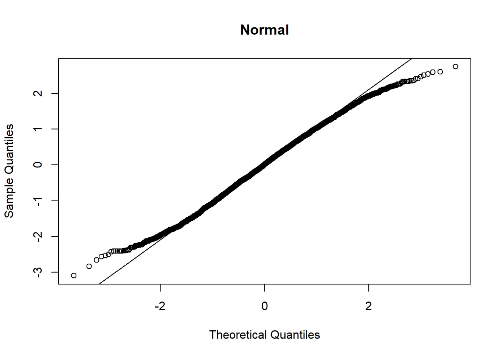

```r
qqnorm(sresids, main='Normal')
qqline(sresids)
```

```r
#qqPlot(sresids)
```

### Intrasubject residuals normality test

We performed an analysis of the normality of the intrasubject residuals with the Shapiro.Wilk method. The study compares subjects (nsubs) according to condition, reporting which ones do not allow us to approve the Null Hypothesis (H0) that residuals come from a normal distribution.

Of all the subjects and conditions evaluated, only 4 do not present a normal distribution in the residuals (4-Wide, 12-Low, 16-Wide and 19-High).

```r
normality_test <- data_clean %>%
  group_by(nsub, condicion) %>%
  summarise(statistic = shapiro.test(res)$statistic,
            p.value = shapiro.test(res)$p.value)

normality_test%>%subset(p.value<0.05)
```

```
## # A tibble: 4 × 4
## # Groups:   nsub [4]
##    nsub condicion statistic p.value
##   <dbl> <chr>         <dbl>   <dbl>
## 1     4 WW            0.900  0.0212
## 2    12 LL            0.906  0.0136
## 3    16 WW            0.910  0.0304
## 4    19 HH            0.898  0.0321
```

### Outliers by Slopes and Incomplete filtering

We applied the MAD (robust median absolute deviation) criterion to eliminate univariate outliers corresponding to the slopes.

Then we eliminate from the table the subjects without an observation for each condition.

```r
slope_1k_WW <- data_slopes %>% filter(Frec=="1k", condicion=="WW")
slope_1k_LL <- data_slopes %>% filter(Frec=="1k", condicion=="LL")
slope_1k_HH <- data_slopes %>% filter(Frec=="1k", condicion=="HH")

slope_4k_WW <- data_slopes %>% filter(Frec=="4k", condicion=="WW")
slope_4k_LL <- data_slopes %>% filter(Frec=="4k", condicion=="LL")
slope_4k_HH <- data_slopes %>% filter(Frec=="4k", condicion=="HH")

# 1k
outliers <-outliers_mad(slope_1k_WW$slope)
#outliers$limits[2]
slope_1k_WW<- slope_1k_WW[slope_1k_WW$slope<outliers$limits[2],]

outliers <-outliers_mad(slope_1k_LL$slope)
#outliers$limits[2]
slope_1k_LL<- slope_1k_LL[slope_1k_LL$slope<outliers$limits[2],]

outliers <-outliers_mad(slope_1k_HH$slope)
#outliers$limits[2]
slope_1k_HH<- slope_1k_HH[slope_1k_HH$slope<outliers$limits[2],]

# 4k
outliers <-outliers_mad(slope_4k_WW$slope)
#outliers$limits[2]
slope_4k_WW<- slope_4k_WW[slope_4k_WW$slope<outliers$limits[2],]

outliers <-outliers_mad(slope_4k_LL$slope)
#outliers$limits[2]
slope_4k_LL<- slope_4k_LL[slope_4k_LL$slope<outliers$limits[2],]

outliers <-outliers_mad(slope_4k_HH$slope)
#outliers$limits[2]
slope_4k_HH<- slope_4k_HH[slope_4k_HH$slope<outliers$limits[2],]

data_slopes_clean <- (rbind(slope_1k_HH,slope_1k_LL,slope_1k_WW,
                            slope_4k_HH,slope_4k_LL,slope_4k_WW))

count_conditions <- data_slopes_clean %>%
  group_by(nsub) %>%
  summarise(n = n())
drops <- count_conditions %>% subset(n!=3)
data_slopes_clean <- data_slopes_clean[!(data_slopes_clean$nsub%in%
                                                 drops$nsub), ]

rm(slope_1k_HH, slope_1k_LL,slope_1k_WW,
   slope_4k_HH,slope_4k_LL,slope_4k_WW)
rm(outliers, count_conditions)
```

### Normality Test Slopes

```r
normality_slopes <- data_slopes_clean %>%
  group_by(Frec, condicion) %>%
  summarise(statistic = shapiro.test(slope)$statistic,
            p.value = shapiro.test(slope)$p.value,
            normality=(p.value>0.05))

normality_slopes
```

```
## # A tibble: 6 × 5
## # Groups:   Frec [2]
##   Frec  condicion statistic p.value normality
##   <chr> <chr>         <dbl>   <dbl> <lgl>
## 1 1k    HH            0.964  0.713  TRUE
## 2 1k    LL            0.894  0.0538 TRUE
## 3 1k    WW            0.897  0.0607 TRUE
## 4 4k    HH            0.910  0.0746 TRUE
## 5 4k    LL            0.871  0.0153 FALSE
## 6 4k    WW            0.976  0.883  TRUE
```

## Boxplot with Slopes

We plotted in a boxplot the total slopes per condition for 1kHz and for 4kHz, noting the degree of significance in the data.

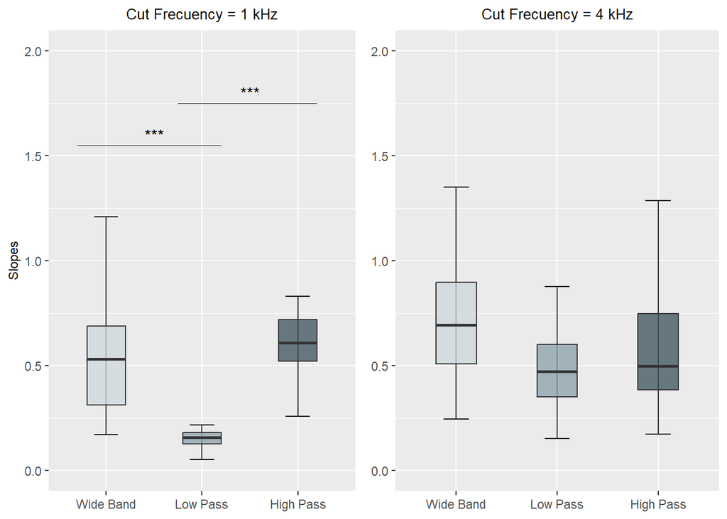

```r
cols <- c("#455A64", "#90A4AE", "#CFD8DC" )

plt_1k_slope <- ggplot(data_slopes_clean %>%
                         filter(Frec=="1k"),
                       aes(x=condicion, y=slope, fill=condicion)) +
  stat_boxplot(geom = "errorbar",
               width = 0.25) +
  geom_boxplot(alpha=0.8, outlier.colour=NA, width = 0.4)+
  scale_x_discrete(limits = c('WW', 'LL', 'HH'),
                   labels = c('Wide Band', 'Low Pass', 'High Pass')) +
  scale_fill_manual(values = cols, guide='none') +
  scale_y_continuous(limits=c(0,2)) +
  labs(title="Cut Frecuency = 1 kHz", y='Slopes')+
  annotate("text", x = 1.5, y = 1.6,  label = "***", size = 4) +
  annotate("segment", x = 0.7, xend = 2.2, y = 1.55,
           yend = 1.55, colour = "black", size=.3, alpha=1,) +
  annotate("text", x = 2.5, y = 1.8,  label = "***", size = 4) +
  annotate("segment", x = 1.75, xend = 3.2, y = 1.75,
           yend = 1.75, colour = "black", size=.3, alpha=1,) +
  theme(axis.title.x = element_blank(),
        axis.title.y = element_text(size = 9),
        plot.title = element_text(size = 10, hjust = 0.5))

plt_4k_slope <- ggplot(data_slopes_clean %>%
                         filter(Frec=="4k" & slope < 1.6),
                       aes(x=condicion, y=slope, fill=condicion)) +
  stat_boxplot(geom = "errorbar",
               width = 0.25) +
  geom_boxplot(alpha = 0.8, outlier.colour=NA, width = 0.4)+
  scale_x_discrete(limits = c('WW', 'LL', 'HH'),
                   labels = c('Wide Band', 'Low Pass', 'High Pass')) +
  scale_fill_manual(values = cols, guide='none') +
  scale_y_continuous(limits=c(0,2)) +
  labs(title="Cut Frecuency = 4 kHz")+
  theme(axis.title.x = element_blank(),
        axis.title.y = element_blank(),
        plot.title = element_text(size = 10, hjust = 0.5))

ggarrange(plt_1k_slope,plt_4k_slope, common.legend = TRUE)
```

## T-test

The results show a significant difference between Low-Wide and Low-High for 1kHz, justifying the data shown in the previous graph.

```r
slope_1k_WW <- data_slopes_clean %>%
  filter(Frec=="1k", condicion=="WW")
slope_1k_LL <- data_slopes_clean %>%
  filter(Frec=="1k", condicion=="LL")
slope_1k_HH <- data_slopes_clean %>%
  filter(Frec=="1k", condicion=="HH")
slope_4k_WW <- data_slopes_clean %>%
  filter(Frec=="4k", condicion=="WW")
slope_4k_LL <- data_slopes_clean %>%
  filter(Frec=="4k", condicion=="LL")
slope_4k_HH <- data_slopes_clean %>%
  filter(Frec=="4k", condicion=="HH")

WW_LL_1k <- t.test(x=slope_1k_WW$slope, slope_1k_LL$slope)
WW_HH_1k <- t.test(x=slope_1k_WW$slope, slope_1k_HH$slope)
LL_HH_1k <- t.test(x=slope_1k_LL$slope, slope_1k_HH$slope)

WW_LL_4k <- t.test(x=slope_4k_WW$slope, slope_4k_LL$slope)
WW_HH_4k <- t.test(x=slope_4k_WW$slope, slope_4k_HH$slope)
LL_HH_4k <- t.test(x=slope_4k_LL$slope, slope_4k_HH$slope)

T_test_condicion <- list(WW_LL_1k = WW_LL_1k$p.value,
                    WW_HH_1k = WW_HH_1k$p.value,
                    LL_HH_1k = LL_HH_1k$p.value,
                    WW_LL_4k = WW_LL_4k$p.value,
                    WW_HH_4k = WW_HH_4k$p.value,
                    LL_HH_4k = LL_HH_4k$p.value)

# Convertimos la lista en un tibble
T_test_condicion <- tibble(Test = names(T_test_condicion), P_Value = unlist(T_test_condicion)) %>% mutate(significance=P_Value<0.05)

rm(WW_HH_1k,LL_HH_1k,WW_LL_1k,WW_LL_4k,WW_HH_4k,LL_HH_4k)
# Mostramos el tibble con los resultados
T_test_condicion
```

```
## # A tibble: 6 × 3
##   Test        P_Value significance
##   <chr>         <dbl> <lgl>
## 1 WW_LL_1k 0.000151   TRUE
## 2 WW_HH_1k 0.618      FALSE
## 3 LL_HH_1k 0.00000106 TRUE
## 4 WW_LL_4k 0.0581     FALSE
## 5 WW_HH_4k 0.110      FALSE
## 6 LL_HH_4k 0.710      FALSE
```

## AnOVa from the linear model

In the ANOVA analysis, we show that the Condition factor is significant for determining slope variation in experiments performed with a cutoff frequency at 1kHz (p-value < 0.001), but not for studies performed with a cutoff frequency of 4kHz.

To see the degree of significance according to condition we performed pairwise comparisons between group levels with bonferroni correction for multiple testing (pairwise.t.test) which exposes the result in more detail.

```r
slopes_1k_clean <- data_slopes_clean%>%filter(Frec=="1k")

lm.1k <-lm(slope~condicion,
               data=slopes_1k_clean)
# summary(lm.1k)
# Este anova no explica cual es el más extremo. Si podemos rechazar la h0 de que todas las medias son iguales
anova(lm.1k)
```

```
## Analysis of Variance Table
##
## Response: slope
##           Df Sum Sq Mean Sq F value    Pr(>F)
## condicion  2 2.1953 1.09764  17.162 2.383e-06 ***
## Residuals 48 3.0700 0.06396
## ---
## Signif. codes:  0 '***' 0.001 '**' 0.01 '*' 0.05 '.' 0.1 ' ' 1
```

```r
pairwise.t.test(slopes_1k_clean$slope,
                slopes_1k_clean$condicion,
                p.adjust.method = "bonferroni")
```

```
##
##  Pairwise comparisons using t tests with pooled SD
##
## data:  slopes_1k_clean$slope and slopes_1k_clean$condicion
##
##    HH      LL
## LL 7.3e-06 -
## WW 1       5.8e-05
##
## P value adjustment method: bonferroni
```

```r
slopes_4k_clean <- data_slopes_clean%>%filter(Frec=="4k")

lm_4k <-lm(slope ~ condicion,
                data=slopes_4k_clean)
#summary(lm_4k)
# Este anova no explica cual es el más extremo. Si podemos rechazar la h0 de que todas las medias son iguales
anova(lm_4k)
```

```
## Analysis of Variance Table
##
## Response: slope
##           Df Sum Sq  Mean Sq F value Pr(>F)
## condicion  2 0.3598 0.179914  2.1942 0.1213
## Residuals 54 4.4277 0.081994
```

```r
pairwise.t.test(slopes_4k_clean$slope,
                slopes_4k_clean$condicion,
                p.adjust.method = "bonferroni")
```

```
##
##  Pairwise comparisons using t tests with pooled SD
##
## data:  slopes_4k_clean$slope and slopes_4k_clean$condicion
##
##    HH   LL
## LL 1.00 -
## WW 0.35 0.16
##
## P value adjustment method: bonferroni
```

## Linear Model with Mixed Effects

Applying this type of linear mixed-effects model adds the subject (nsub) as a random factor. In other words, a subject-condition interaction is added.

This analysis allows to evaluate the variation of slopes between intrasubject conditions.

[Reference](https://www.youtube.com/watch?v=AWInLxpiZuA)

### LMER en 1k

```r
lmer.1k <- lmer(slope ~ condicion + (1|nsub),
    data = slopes_1k_clean)

anova(lmer.1k)
```

```
## Type III Analysis of Variance Table with Satterthwaite's method
##           Sum Sq Mean Sq NumDF DenDF F value    Pr(>F)
## condicion 2.1953  1.0976     2    32   29.84 4.852e-08 ***
## ---
## Signif. codes:  0 '***' 0.001 '**' 0.01 '*' 0.05 '.' 0.1 ' ' 1
```

```r
##partial eta sq
effectsize::eta_squared(lmer.1k, partial = TRUE)
```

```
## # Effect Size for ANOVA (Type III)
##
## Parameter | Eta2 (partial) |       95% CI
## -----------------------------------------
## condicion |           0.65 | [0.47, 1.00]
##
## - One-sided CIs: upper bound fixed at [1.00].
```

```r
#Rsq
r.squaredGLMM(lmer.1k)
```

```
##            R2m       R2c
## [1,] 0.4070468 0.6589804
```

```r
emmeans(lmer.1k,
        list(pairwise ~ condicion),
        adjust="bonferroni")
```

```
## $`emmeans of condicion`
##  condicion emmean     SE   df lower.CL upper.CL
##  HH         0.630 0.0613 35.3   0.5055    0.754
##  LL         0.166 0.0613 35.3   0.0414    0.290
##  WW         0.577 0.0613 35.3   0.4528    0.702
##
## Degrees-of-freedom method: kenward-roger
## Confidence level used: 0.95
##
## $`pairwise differences of condicion`
##  1       estimate     SE df t.ratio p.value
##  HH - LL   0.4641 0.0658 32   7.055  <.0001
##  HH - WW   0.0527 0.0658 32   0.801  1.0000
##  LL - WW  -0.4114 0.0658 32  -6.254  <.0001
##
## Degrees-of-freedom method: kenward-roger
## P value adjustment: bonferroni method for 3 tests
```

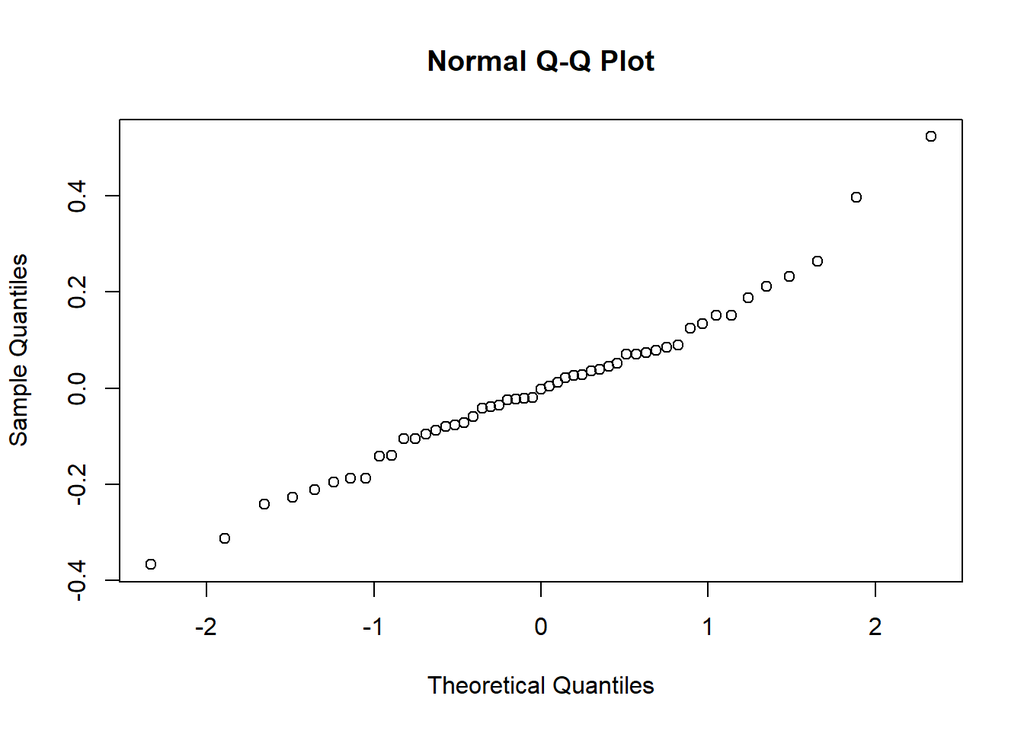

```r
qqnorm(resid(lmer.1k))
```

### LMER in 4k

```r
lmer.4k <- lmer(slope ~ condicion + (1|nsub),
    data = slopes_4k_clean)

anova(lmer.4k)
```

```
## Type III Analysis of Variance Table with Satterthwaite's method
##            Sum Sq Mean Sq NumDF DenDF F value  Pr(>F)
## condicion 0.35983 0.17991     2    36  2.8901 0.06854 .
## ---
## Signif. codes:  0 '***' 0.001 '**' 0.01 '*' 0.05 '.' 0.1 ' ' 1
```

```r
##partial eta sq
effectsize::eta_squared(lmer.4k, partial = TRUE)
```

```
## # Effect Size for ANOVA (Type III)
##
## Parameter | Eta2 (partial) |       95% CI
## -----------------------------------------
## condicion |           0.14 | [0.00, 1.00]
##
## - One-sided CIs: upper bound fixed at [1.00].
```

```r
#Rsq
r.squaredGLMM(lmer.4k)
```

```
##            R2m       R2c
## [1,] 0.0726709 0.2959578
```

```r
emmeans(lmer.4k,
        list(pairwise ~ condicion),
        adjust="bonferroni")
```

```
## $`emmeans of condicion`
##  condicion emmean     SE   df lower.CL upper.CL
##  HH         0.577 0.0657 48.4    0.445    0.709
##  LL         0.541 0.0657 48.4    0.409    0.673
##  WW         0.725 0.0657 48.4    0.593    0.857
##
## Degrees-of-freedom method: kenward-roger
## Confidence level used: 0.95
##
## $`pairwise differences of condicion`
##  1       estimate     SE df t.ratio p.value
##  HH - LL   0.0356 0.0809 36   0.439  1.0000
##  HH - WW  -0.1479 0.0809 36  -1.827  0.2278
##  LL - WW  -0.1835 0.0809 36  -2.267  0.0885
##
## Degrees-of-freedom method: kenward-roger
## P value adjustment: bonferroni method for 3 tests
```

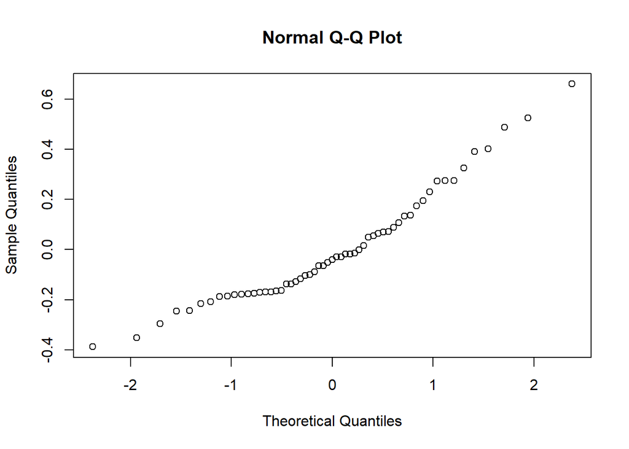

```r
qqnorm(resid(lmer.4k))
```

## EXTRA: boxplot by block order

We performed an analysis of slopes by condition according to the order of occurrence of the stimuli during the experiment. This allows us to evaluate whether the compression of the slopes is related to the order of appearance.

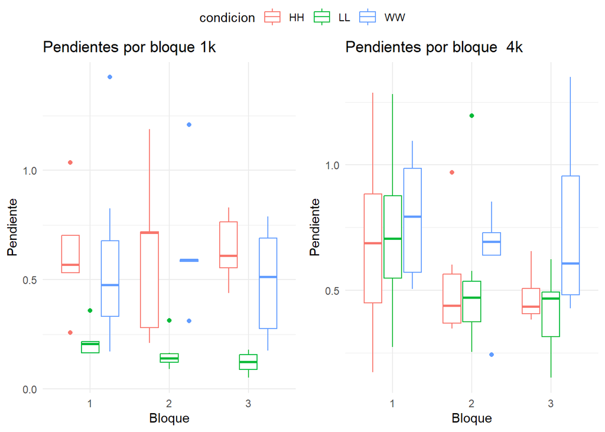

```r
# ggplot(data=slopes_corregida%>%filter(Frec=="1k"), aes(x=as.character(orden), y=slope,color=condicion))+
#   geom_boxplot()+
#   geom_point(position = "jitter")+
#   xlab("Bloque")+
#   ylab("Pendiente")+
#   theme_minimal()

plt_1k_per_block <- ggplot(slopes_1k_clean,
                           aes(x=as.character(orden),
                               y=slope,color=condicion)) +
  geom_boxplot()+
  #geom_point(position = "jitter")+
  xlab("Bloque")+
  ylab("Pendiente")+
  labs(title="Pendientes por bloque 1k")+
  theme_minimal()

plt_4k_per_block <- ggplot(slopes_4k_clean,
                           aes(x=as.character(orden),
                               y=slope,color=condicion)) +
  geom_boxplot()+
  #geom_point(position = "jitter")+
  xlab("Bloque")+
  ylab("Pendiente")+
  labs(title="Pendientes por bloque  4k")+
  theme_minimal()

ggarrange(plt_1k_per_block,plt_4k_per_block, common.legend = TRUE)
```